# Using Riding Patterns of Ford GoBike Riding Service to Determine The Lifestyle of Users

## by AKEEM Ridwanulahi Akeem

## Investigation Overview

In this report, I want to investigate how features like speed, distance, days can be used to determine the the lifestyle of the users of the Ford GoBike Riding Services.

## Dataset Overview

The dataset contains information about he Ford GoBike System data which includes information about individual rides made in a bike sharing system covering the greater San Francisco Bay area. The dataset features 183412 rows and 17 columns and the columns were extended to 31 columns to provide room for more insightful variables which helped the investigation while the rows were pruned to 173272 rows after cleaning.

## Distribution of Rides by hours of the day and day of the week

The number of rides per hour of the day and day of week can be observed in the chart below. From the chart, it can be seen that:

1. Most trips happens at 8th and 17th hour of the day - a proof that most users are working class and use it to commute to and fro work
2. We have more trips between Mondays and Fridays with Thursday having the most trip per day

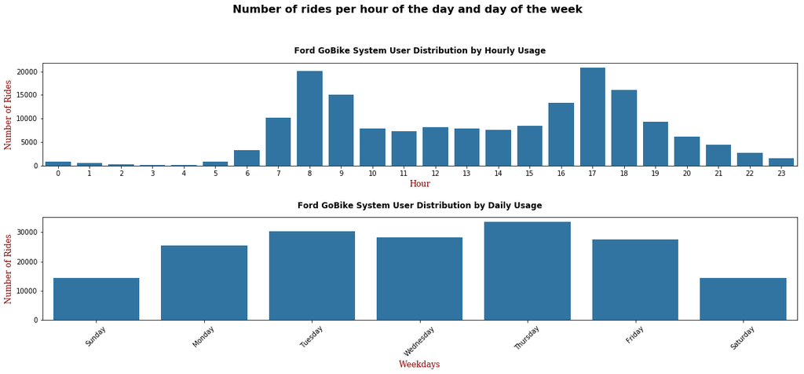

## Relationship between speed, distance, duration and category of the users of the service

The chart below show the relationship between the speed, distance, duration in respect to the category of users in order to understand the riding patterns of users and define them properly. The observations can be made from the chart:

1. The customer category of users can be observed to ride slower over a longer distance for a longer period of time giving credence that the customers are not working class people but people on leisure probably tourists who came on vacation
2. The Subscriber category of users can be observed to ride faster for a short of period of time over a short distance which is in complete opposition to the customers' riding pattern giving credence that the subscribers are working class people living and working with the area.

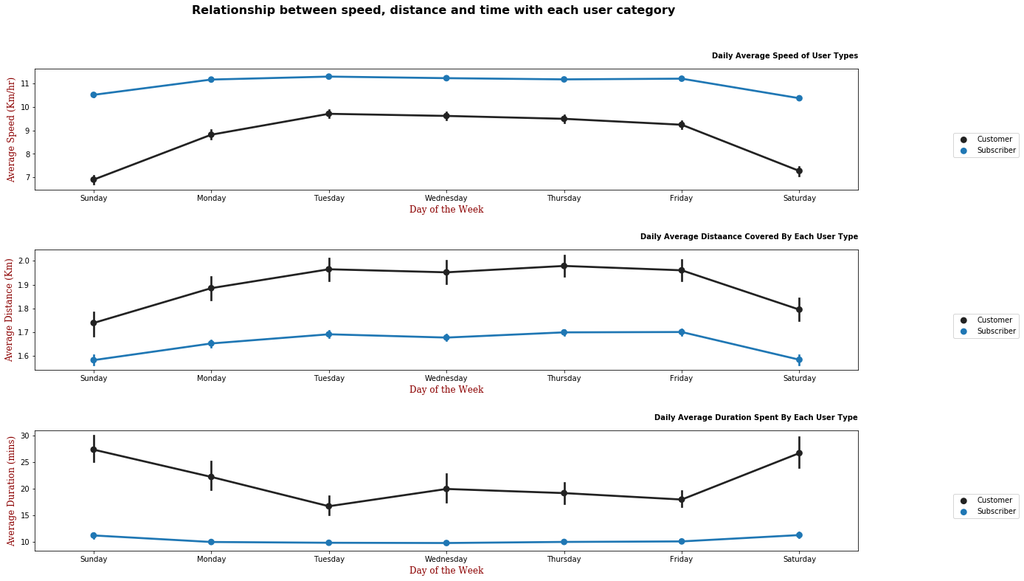

## Determining The Most Active Days for Each Category of User

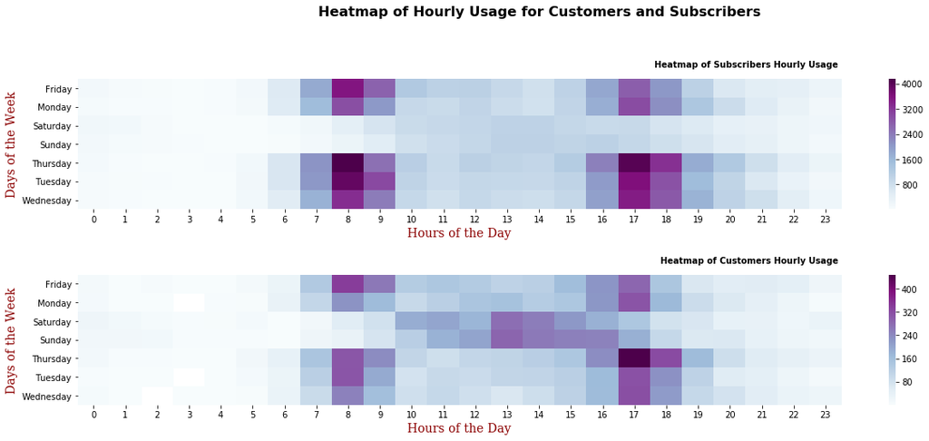